# Evaluating Discards using Observer Data - Guyana`s Shrimp Fishery

Seion Richardson

November 02, 2020

# 1 FIRST SUBMISSION

```r
library(tidyverse) ### [1]. Summarize data and make plots
library(skimr) ### [2]. Summarizes data with descriptive statistics
library(flextable) ### [3]. Creates neat tables
library(kableExtra) ### [4]. Also creates tables
```

```r
ObserverData <- read_csv("observer_weights_mas102m.csv")

###=== COMMENTS START ===###
### [1]. Importing the observer data using the read_csv() function from the tidyverse package. The imported data is called "ObserverData" in this project.
###=== COMMENTS END ===###
```

## 1.1 Definition of Key terms

**Total catch** - the amount of fish caught by a fishing gear that reaches the vessels deck.

**Target catch** - the main species which are sought after by a particular fishery e.g. cod or shrimp.

**Incidental catch** - the species caught which are retained for consumption or marketing purposes.

**Discarded catch** - the section of catch returned to the sea, usually dead or alive due to economic or legal considerations.

**Bycatch** - Discarded catch combined with incidental catch.

**Fishery observer** - is a specialist trained in collecting data onboard commercial fishing vessels.

**Observer data** - data collected at-sea by fishery observers.

**Drag** - The act of fishing or trawling.

**CPUE** - Catch per unit effort i.e. the fish caught per unit of effort e.g. kgs/hr.

## 1.2 Data description

The data used in this project is on discarded catch from a shrimp fishery in Guyana, South America. The data was collected at-sea by fishery observers onboard Atlantic seabob shrimp trawl vessels between 2019 to 2020. The data was collected within the seabob trawling zone i.e. 8 to 18 fathoms water depth (see Figure 1). It includes sampled bottom trawl data from 8 distinct fishing trips with an average of 6 sampled hauls per trip (3 days, 3 nights) and different fishing depths (shallow, deep) (Figure 2). A total of seven fishing vessels were used from two fishing companies. Other key variables measured included the fishing duration (days-at-sea) and trip lengths.

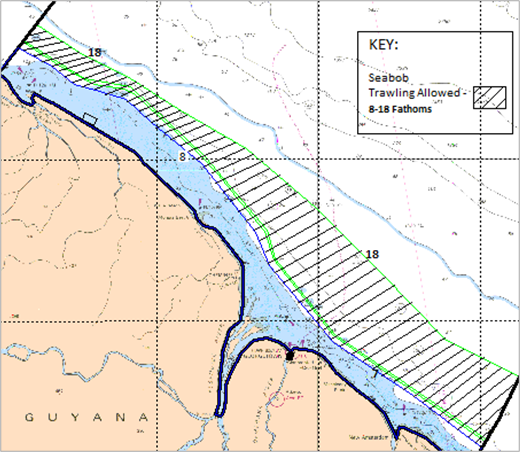

Figure 1 Seabob trawling zone (8 and 18-fathom lines) within the EEZ. Modified from (Maison 2015)

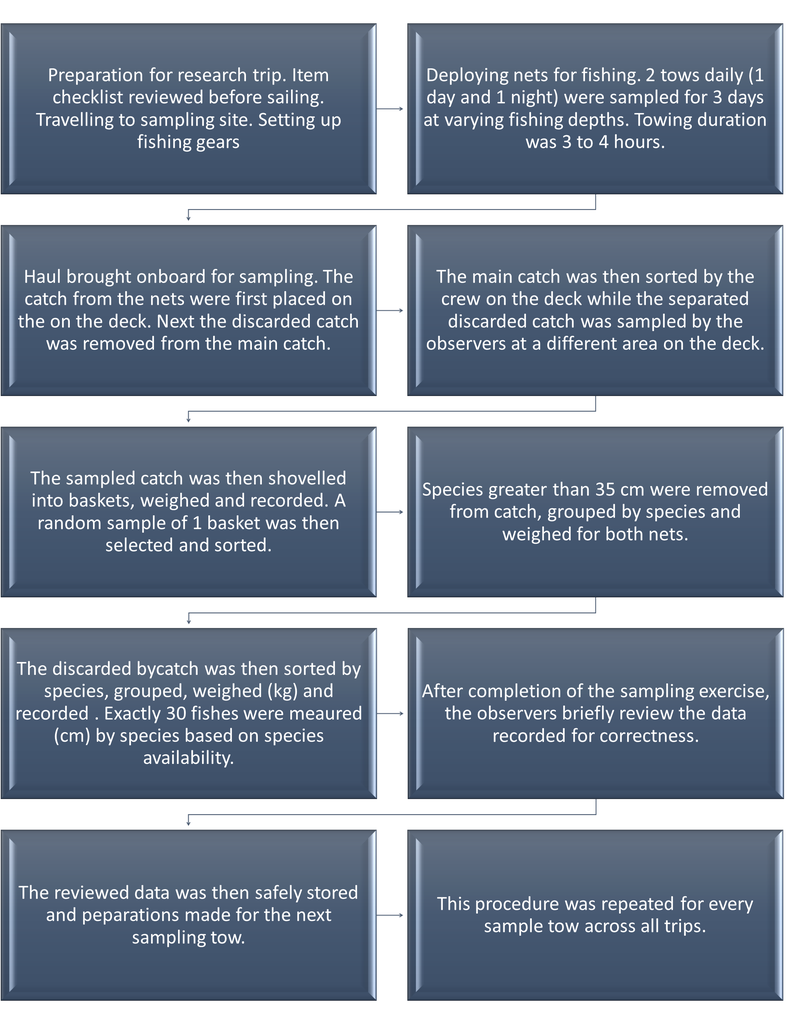

Figure 2 Data collection sampling protocol

### 1.2.2 First 10 rows from data

```r
First10Rows <- head(ObserverData, 10) %>%
  kable("html") %>%
  kable_styling("striped") %>%
  scroll_box(width = "100%")

###=== COMMENTS START ===###
### [1]. A peek at first 10 rows in data using the head() function.
### ==========
### [2]. The kable() function used create a scrollable html table. This is useful for data with many variables like this one.
###=== COMMENTS END ===###

First10Rows
```

| company | dep_date | arr_date | das | trip | drag | drag_all | drag_date | drag_period | drag_time_s | drag_time_e | time_fished_min | hrs_dec | depth | depth_sd | id_status | com_status | order | family | class | total_catch_cat | total_catch_spp | categories | sci_name | alpha_code | com_name | sample_wt_lbs | total_wt_lbs | cpue |
| --- | --- | --- | --- | --- | --- | --- | --- | --- | --- | --- | --- | --- | --- | --- | --- | --- | --- | --- | --- | --- | --- | --- | --- | --- | --- | --- | --- | --- |
| NHS | 14/02/2019 | 24/02/2019 | 11 | 1 | 1 | 1 | 15/02/2019 | Day | 08:00:00 | 12:00:00 | 04:00:00 | 4 | 10 | Deep | Yes | No | Perciformes | Sciaenidae | Actinopterygii | Discarded catch | Bycatch species | Bony fish | Paralonchurus brasiliensis | RLB | Banded croaker | 0.50 | 1.26 | 0.3150 |
| NHS | 14/02/2019 | 24/02/2019 | 11 | 1 | 1 | 1 | 15/02/2019 | Day | 08:00:00 | 12:00:00 | 04:00:00 | 4 | 10 | Deep | Yes | Yes | Perciformes | Sciaenidae | Actinopterygii | Discarded catch | Bycatch species | Bony fish | Macrodon ancylodon | WKK | Bangamary | 3.00 | 7.58 | 1.8950 |
| NHS | 14/02/2019 | 24/02/2019 | 11 | 1 | 1 | 1 | 15/02/2019 | Day | 08:00:00 | 12:00:00 | 04:00:00 | 4 | 10 | Deep | Yes | No | Decapoda | Malacostraca | Malacostraca | Discarded catch | Bycatch species | Shell fish | Hepatus gronovii | HGV | Box crab | 0.70 | 1.77 | 0.4425 |
| NHS | 14/02/2019 | 24/02/2019 | 11 | 1 | 1 | 1 | 15/02/2019 | Day | 08:00:00 | 12:00:00 | 04:00:00 | 4 | 10 | Deep | Yes | Yes | Perciformes | Sciaenidae | Actinopterygii | Discarded catch | Bycatch species | Bony fish | Nebris microps | NBM | Butterfish | 3.00 | 7.58 | 1.8950 |
| NHS | 14/02/2019 | 24/02/2019 | 11 | 1 | 1 | 1 | 15/02/2019 | Day | 08:00:00 | 12:00:00 | 04:00:00 | 4 | 10 | Deep | Yes | Yes | Siluriformes | Ariidae | Actinopterygii | Discarded catch | Bycatch species | Bony fish | Bagre bagre | BEB | Catfish | 4.30 | 10.87 | 2.7175 |
| NHS | 14/02/2019 | 24/02/2019 | 11 | 1 | 1 | 1 | 15/02/2019 | Day | 08:00:00 | 12:00:00 | 04:00:00 | 4 | 10 | Deep | Yes | Yes | Perciformes | Sciaenidae | Actinopterygii | Discarded catch | Bycatch species | Bony fish | Lonchurus elegans | RLE | Chinese butterfish | 6.30 | 15.93 | 3.9825 |
| NHS | 14/02/2019 | 24/02/2019 | 11 | 1 | 1 | 1 | 15/02/2019 | Day | 08:00:00 | 12:00:00 | 04:00:00 | 4 | 10 | Deep | Yes | No | Perciformes | Sciaenidae | Actinopterygii | Discarded catch | Bycatch species | Bony fish | Stellifer microps | EFM | Croaker lm | 12.00 | 30.34 | 7.5850 |
| NHS | 14/02/2019 | 24/02/2019 | 11 | 1 | 1 | 1 | 15/02/2019 | Day | 08:00:00 | 12:00:00 | 04:00:00 | 4 | 10 | Deep | Yes | No | Perciformes | Sciaenidae | Actinopterygii | Discarded catch | Bycatch species | Bony fish | Stellifer rastrifer | EFR | Croaker rm | 20.00 | 50.57 | 12.6425 |
| NHS | 14/02/2019 | 24/02/2019 | 11 | 1 | 1 | 1 | 15/02/2019 | Day | 08:00:00 | 12:00:00 | 04:00:00 | 4 | 10 | Deep | Yes | No | Pleuronectiformes | Achiridae | Actinopterygii | Discarded catch | Bycatch species | Flat fish | Achirus achirus | HIK | Drab sole | 0.75 | 1.90 | 0.4750 |
| NHS | 14/02/2019 | 24/02/2019 | 11 | 1 | 1 | 1 | 15/02/2019 | Day | 08:00:00 | 12:00:00 | 04:00:00 | 4 | 10 | Deep | Yes | Yes | Not applicable | Not applicable | Not applicable | Incidental catch | Bycatch species | Bony fish | Multiple species finfish | Not applicable | Finfish | 0.00 | 10.83 | 2.7075 |

### 1.2.3 Renaming variables

```r
ObserverData <-  ObserverData %>%
  dplyr::rename(Company = company,
                Departure = dep_date,
                Arrival = arr_date,
                DaysAtSea = das,
                TripID = trip,
                DragID = drag,
                DragID2 = drag_all,
                DragDate = drag_date,
                TimePeriods = drag_period,
                DragStart = drag_time_s,
                DragEnd = drag_time_e,
                TimeFishedHrs = time_fished_min,
                TimeFishedDec = hrs_dec,
                FishingDepth = depth,
                FishingDepth2 = depth_sd,
                SpeciesID = id_status,
                EconomicStatus = com_status,
                OrderTax = order,
                FamilyTax = family,
                ClassTax = class,
                CatchCategory = total_catch_cat,
                SpeciesCategory = total_catch_spp,
                SpeciesCategory2 = categories,
                LatinNames = sci_name,
                AplhaCode = alpha_code,
                CommonName = com_name,
                SampleWeightLB = sample_wt_lbs,
                TotalWeightLB = total_wt_lbs,
                CpueLBHR = cpue)

###=== COMMENTS START ===###
### [1]. The rename() function from the dplyr package was used to give the variables descriptive names.
###=== COMMENTS END ===###

NewNames <- names(ObserverData)

###=== COMMENTS START ===###
### [2]. A quick view of the renamed variables using the names() function from base R.
###=== COMMENTS END ===###

NewNames
```

```
   [1] "Company"          "Departure"        "Arrival"          "DaysAtSea"
   [5] "TripID"           "DragID"           "DragID2"          "DragDate"
   [9] "TimePeriods"      "DragStart"        "DragEnd"          "TimeFishedHrs"
  [13] "TimeFishedDec"    "FishingDepth"     "FishingDepth2"    "SpeciesID"
  [17] "EconomicStatus"   "OrderTax"         "FamilyTax"        "ClassTax"
  [21] "CatchCategory"    "SpeciesCategory"  "SpeciesCategory2" "LatinNames"
  [25] "AplhaCode"        "CommonName"       "SampleWeightLB"   "TotalWeightLB"
  [29] "CpueLBHR"
```

### 1.2.4 Creating a few additonal variables

Three new variables will be added. These variables will change the current weight units from **Imperial** to **Metric** (i.e. pounds to kilograms)which is more common in Europe.

```r
ObserverData <- ObserverData %>%
  mutate(SampleWeightKG = SampleWeightLB/2.2,
    TotalWeightKG = TotalWeightLB/2.2,
    CpueKGHR = TotalWeightKG/TimeFishedDec
    )

###=== COMMENTS START ===###
### [1]. Convert from pounds to kilograms.
### ==========
### [2]. The mutate() function from the dplyr package is passed to the data "ObserverData" to create two new variables: "SampleWeightKG" and "TotalweightKG".
###=== COMMENTS END ===###

NewVarNames <- names(ObserverData)

###=== COMMENTS START ===###
### [3]. A quick view of the new variables using the names() function from base R.
###=== COMMENTS END ===###

NewVarNames
```

```
   [1] "Company"          "Departure"        "Arrival"          "DaysAtSea"
   [5] "TripID"           "DragID"           "DragID2"          "DragDate"
   [9] "TimePeriods"      "DragStart"        "DragEnd"          "TimeFishedHrs"
  [13] "TimeFishedDec"    "FishingDepth"     "FishingDepth2"    "SpeciesID"
  [17] "EconomicStatus"   "OrderTax"         "FamilyTax"        "ClassTax"
  [21] "CatchCategory"    "SpeciesCategory"  "SpeciesCategory2" "LatinNames"
  [25] "AplhaCode"        "CommonName"       "SampleWeightLB"   "TotalWeightLB"
  [29] "CpueLBHR"         "SampleWeightKG"   "TotalWeightKG"    "CpueKGHR"
```

### 1.2.5 Data summary

```r
SkimData <- skim(ObserverData) %>%
  skim_without_charts()

###=== COMMENTS START ===###
### [1]. The skim() function from the "skimr" package was used to get a quick summary of the variables from the data.
###==========
### [2]. The skim_without_charts() function from the "skimr" package was used to summarise the data without histograms since the histograms were only printing in Rstudio but not in the html output.
###==========
### [3]. All the data seems to fit nicely into the categories character, difftime and numeric. Only the dates variables need to be converted to the correct format. This was not done in this submission as dates were not needed. However, if it is required for the other submissions, they will be formatted correctly.
###=== COMMENTS END ===###

SkimData
```

Data summary

| Name | Piped data |
| --- | --- |
| Number of rows | 32 |
| Number of columns | 21 |
| _______________________ |  |
| Column type frequency: |  |
| character | 3 |
| difftime | 3 |
| numeric | 15 |
| ________________________ |  |
| Group variables | None |

**Variable type: character**

| skim_variable | n_missing | complete_rate | min | max | empty | n_unique | whitespace |
| --- | --- | --- | --- | --- | --- | --- | --- |
| skim_type | 0 | 1.00 | 7 | 9 | 0 | 3 | 0 |
| skim_variable | 0 | 1.00 | 6 | 16 | 0 | 32 | 0 |
| numeric.hist | 20 | 0.38 | 5 | 5 | 0 | 7 | 0 |

**Variable type: difftime**

| skim_variable | n_missing | complete_rate | min | max | median | n_unique |
| --- | --- | --- | --- | --- | --- | --- |
| difftime.min | 29 | 0.09 | 1200 secs | 4200 secs | 01:00:00 | 3 |
| difftime.max | 29 | 0.09 | 19920 secs | 86340 secs | 20:30:00 | 3 |
| difftime.median | 29 | 0.09 | 14100 secs | 46800 secs | 09:30:00 | 3 |

**Variable type: numeric**

| skim_variable | n_missing | complete_rate | mean | sd | p0 | p25 | p50 | p75 | p100 |
| --- | --- | --- | --- | --- | --- | --- | --- | --- | --- |
| n_missing | 0 | 1.00 | 2.34 | 13.26 | 0.00 | 0.00 | 0.00 | 0.00 | 75.00 |
| complete_rate | 0 | 1.00 | 1.00 | 0.01 | 0.94 | 1.00 | 1.00 | 1.00 | 1.00 |
| character.min | 15 | 0.53 | 6.35 | 3.69 | 2.00 | 3.00 | 5.00 | 10.00 | 14.00 |
| character.max | 15 | 0.53 | 12.24 | 7.28 | 3.00 | 7.00 | 10.00 | 16.00 | 27.00 |
| character.empty | 15 | 0.53 | 0.00 | 0.00 | 0.00 | 0.00 | 0.00 | 0.00 | 0.00 |
| character.n_unique | 15 | 0.53 | 19.65 | 25.00 | 2.00 | 2.00 | 8.00 | 31.00 | 79.00 |
| character.whitespace | 15 | 0.53 | 0.00 | 0.00 | 0.00 | 0.00 | 0.00 | 0.00 | 0.00 |
| difftime.n_unique | 29 | 0.09 | 32.00 | 10.15 | 21.00 | 27.50 | 34.00 | 37.50 | 41.00 |
| numeric.mean | 20 | 0.38 | 9.83 | 10.03 | 0.88 | 3.78 | 6.12 | 10.51 | 33.64 |
| numeric.sd | 20 | 0.38 | 13.91 | 22.24 | 0.55 | 1.78 | 3.07 | 14.97 | 76.74 |
| numeric.p0 | 20 | 0.38 | 1.17 | 1.85 | 0.00 | 0.00 | 0.50 | 1.00 | 5.00 |
| numeric.p25 | 20 | 0.38 | 3.62 | 3.72 | 0.05 | 0.99 | 2.57 | 5.04 | 13.00 |
| numeric.p50 | 20 | 0.38 | 7.38 | 7.59 | 0.20 | 2.84 | 5.10 | 8.46 | 26.00 |
| numeric.p75 | 20 | 0.38 | 11.02 | 11.31 | 0.77 | 4.06 | 7.49 | 11.07 | 36.00 |
| numeric.p100 | 20 | 0.38 | 206.94 | 380.40 | 5.53 | 10.25 | 32.73 | 189.09 | 1280.00 |

## 1.3 Summary of key research variables

This research will look into discarded catch **weights, lengths and catch rates (CPUE)** and more specifically to measure them against **fishing depths and time-periods**.

### 1.3.1 Count of species sampled by trip and time-period

Here we see that data was across eight fishing trips. For each of those trip sampling was done across Day and Night time-periods i.e. 8 respectively. The number of Samples collected ranged from 54 (Trip 8 - Day) to 89 (Trip 6 - Day) with the mean number sampled being 67.

```r
DiscardData <- ObserverData %>%
  filter(CatchCategory == "Discarded catch")

###=== COMMENTS START ===###
### [1]. Creating a new object "DiscardData" with the discard data only which will be the main focus of this project.
###=== COMMENTS END ===###

Table1 <- DiscardData %>%
  group_by(TripID, TimePeriods) %>%
  dplyr::summarise(Count = n(),
                   .groups = 'drop') %>%
  arrange(TripID)

###=== COMMENTS START ===###
### [2]. Creating table object called "Table1".
### ==========
### [3]. The group_by() function was used group the data by fishing trip and time-period (day, night).
### ==========
### [4]. The summarise() function was called directly from the package using the command "package name::function" due to clashes with other packages.
### [5]. The summarise() function was then used to produce a summary of count observations.
### ==========
### [6]. The ".group" argument was used to control the grouping structure of the output, in this case it was dropped.
### ==========
### [7]. Lastly, the table was sorted by the "TripID" variable in ascending order using the arrange() function. The functions used in this code were all from the dplyr package.
###=== COMMENTS END ===###

colnames(Table1) <-c("Fishing Trips",
                     "Time Period",
                     "Counts")

###=== COMMENTS START ===###
### [8]. Used to rename the variables from "Table1" with descriptive names.
###=== COMMENTS END ===###

Table1 <- Table1 %>%
  flextable() %>%
  autofit(add_w = 2) %>%
  align_text_col(align = "left") %>%
  align_nottext_col(align = "left") %>%
  bg(bg = "#8DD3C7", part = "header") %>%
  color(color = "white", part = "header")  %>%
  set_caption("Table 1 Count of species sampled across fishing trips and time-periods. Day = 6:00 hrs to 17:59 hrs and Night = 18:00 hrs to 5:59 hrs.  ")

###=== COMMENTS START ===###
### [9]. The object "Table1" was then passed to flextable function to format the table.
### ==========
### [10]. The columns were autofit to window using the autofit() function with the add_w argument.
### ==========
### [11]. Both texts and columns were aligned left using align_text_col() and align_nottext_col() functions.
### ==========
### [12]. The bg() and color() functions were used to set the color of the table header.
### ==========
### [13]. Lastly, he table caption was created using the set_caption() function.
### ==========
### [14].The functions used in this code were all from the flextable package.
###=== COMMENTS END ===###

Table1
```

Table 1 Count of species sampled across fishing trips and time-periods. Day = 6:00 hrs to 17:59 hrs and Night = 18:00 hrs to 5:59 hrs.

| Fishing Trips | Time Period | Counts |
| --- | --- | --- |
| 1 | Day | 70 |
| 1 | Night | 58 |
| 2 | Day | 68 |
| 2 | Night | 55 |
| 3 | Day | 75 |
| 3 | Night | 57 |
| 4 | Day | 55 |
| 4 | Night | 61 |
| 5 | Day | 75 |
| 5 | Night | 70 |
| 6 | Day | 89 |
| 6 | Night | 88 |
| 7 | Day | 66 |
| 7 | Night | 72 |
| 8 | Day | 54 |
| 8 | Night | 60 |

### 1.3.2 Count of species sampled by trip and fishing depth

Here we see that data was across eight fishing trips. The samples were randomly collected across Deep and Shallow water depths. The number of samples collected ranged from 41 (Trip 3 - Shallow) to 177 (Trip 6 - Shallow) with the mean number sampled being 98.

```r
Table2 <- DiscardData %>%
  group_by(TripID,
           FishingDepth2) %>%
  dplyr::summarise(Count = n(),
                   .groups = 'drop') %>%
   dplyr::arrange(TripID)

colnames(Table2) <-c("Fishing Trips",
                     "Fishing Depths",
                     "Counts")

Table2 <- Table2 %>%
 flextable() %>%
  autofit(add_w = 2) %>%
  align_text_col(align = "left") %>%
  align_nottext_col(align = "left") %>%
  bg(bg = "midnightblue", part = "header") %>%
  color(color = "white", part = "header") %>%
  set_caption("Table 2 Count of species sampled across fishing trips and dishing depths. Deep = above 9 fathoms and Shallow = equal to or less than 9 fathoms. ")

###=== COMMENTS START ===###
### ==========
### [1]. All of the comments in this code are similar to that of "Table 1" except that Fishing depth (i.e. "FishingDepth2") has replaced "TimePeriods".
###=== COMMENTS END ===###

Table2
```

Table 2 Count of species sampled across fishing trips and dishing depths. Deep = above 9 fathoms and Shallow = equal to or less than 9 fathoms.

| Fishing Trips | Fishing Depths | Counts |
| --- | --- | --- |
| 1 | Deep | 86 |
| 1 | Shallow | 42 |
| 2 | Deep | 123 |
| 3 | Deep | 91 |
| 3 | Shallow | 41 |
| 4 | Deep | 71 |
| 4 | Shallow | 45 |
| 5 | Shallow | 145 |
| 6 | Shallow | 177 |
| 7 | Shallow | 138 |
| 8 | Deep | 114 |

## 1.4 Research Questions

### 1.4.1 First Submission

1. What were the species discarded and their relative proportions?
2. What proportions of the total catch were discarded?

### 1.4.2 Second Submission

3. What are the weight distributions of the most common species discarded across time-periods and fishing depths?
4. Are the mean species weights equal across time-periods and fishing depths?

### 1.4.3 Third Submission (Joining weight and length data)

5. What were the length distributions of the most common species discarded across time-periods and fishing depths?
6. Are the mean lengths for all species equal across time-periods and fishing depths?

## 1.5 Hypotheses

$H_O$ (Null hypothesis) – Mean species weights and lengths are **equal** across time-periods.

$H_A$ (Alternate hypothesis) - Mean species weights and lengths are **not equal** across time-periods.

$H_O$ (Null hypothesis) – Mean species weights and lengths are **equal** across fishing depths.

$H_A$ (Alternate hypothesis) – Mean species weights and lengths are **not equal** across fishing depths.

## 1.6 Species discarded and their relative proportions (Research question 1)

```r
Table3 <- DiscardData %>%
  group_by(OrderTax,
           FamilyTax,
           LatinNames) %>%
  dplyr::summarise(n = n(),
                   prop = round(n/48,2),
                   .groups = 'drop') %>%
  arrange(OrderTax)

###=== COMMENTS START ===###
### [1]. The group_by() function was used create a species Taxonomy table containing the Order, Family and Latin/Scientific names.
### ==========
### [2]. A new variable "prop" which calculated species proportion based on abundance/count within the data was created using the summarise() function.
### ==========
### [3]. The table was arranged by Order.
### ==========
### [4]. See comments from "Table 1" for more details.
###=== COMMENTS END ===###

Table3$OrderTax = ifelse(duplicated(Table3$OrderTax), "",
                         Table3$OrderTax)
Table3$FamilyTax = ifelse(duplicated(Table3$FamilyTax), "",
                          Table3$FamilyTax)

###=== COMMENTS START ===###
### [5]. The "ifelse and duplicated" functions from base R was used to remove duplicated Order and family names from "Table3". This will make the table look less clustered and more easily readable.
###=== COMMENTS END ===###

colnames(Table3) <-c("Orders",
                     "Families",
                     "Scientific names",
                     "Counts", "Proportion")

###=== COMMENTS START ===###
### [6]. The colnames() function was used to rename "Table3" variables with descriptive names.
###=== COMMENTS END ===###

Table3 <- Table3 %>%
  flextable() %>%
  autofit(add_w = 0.5) %>%
  align_text_col(align = "left") %>%
  align_nottext_col(align = "left") %>%
  bg(bg = "#C90000", part = "header") %>%
  color(color = "white", part = "header") %>%
  color(~ Proportion >= 0.5, ~ Proportion, color = "blue") %>%
  bold(~ Proportion >= 0.5, ~ Proportion, bold = TRUE) %>%
    set_caption("Table 3 Fish taxa identified from the 48 bottom-trawl hauls sampled off the coast of Guyana. Where p = species presence in proportion within the total samples.Blue fonts  highlights species p of >= 0.5")

###=== COMMENTS START ===###
### [7]. All comments here are similar to "Table1" except for:
### ==========
### [8]. The Proportions greater greater than or equal to 0.5 were colored blue using the color() function and bolded using the bold() function.
###=== COMMENTS END ===###

Table3
```

Table 3 Fish taxa identified from the 48 bottom-trawl hauls sampled off the coast of Guyana. Where p = species presence in proportion within the total samples.Blue fonts highlights species p of >= 0.5

| Orders | Families | Scientific names | Counts | Proportion |
| --- | --- | --- | --- | --- |
| Anguilliformes | Muraenidae | Gymnothorax ocellatus | 1 | 0.02 |
|  | Ophichthidae | Ophichthus gomesii | 37 | 0.77 |
| Batrachoidiformes | Batrachoididae | Batrachoides surinamensis | 34 | 0.71 |
|  |  | Porichthys pauciradiatus | 1 | 0.02 |
| Carcharhiniformes | Triakidae | Mustelus higmani | 6 | 0.12 |
| Clupeiformes | Clupeidae | Harengula jaguana | 27 | 0.56 |
|  | Engraulidae | Anchoa mitchilli | 22 | 0.46 |
|  |  | Anchoa spinifer | 18 | 0.38 |
|  |  | Anchoviella lepidentostole | 1 | 0.02 |
| Decapoda | Aethridae | Hepatus pudibundus | 3 | 0.06 |
|  | Calappidae | Calappa sulcata | 1 | 0.02 |
|  | Diogenidae | Clibanarius foresti | 2 | 0.04 |
|  |  | Petrochirus diogenes | 1 | 0.02 |
|  | Inachoididae | Paulita tuberculata | 3 | 0.06 |
|  | Leucosiidae | Persephona lichtensteinii | 21 | 0.44 |
|  | Malacostraca | Hepatus gronovii | 24 | 0.50 |
|  | Portunidae | Callinectes ornatus | 47 | 0.98 |
| Elopiformes | Elopidae | Elops saurus | 1 | 0.02 |
| Lophiiformes | Ogcocephalidae | Ogcocephalus darwini | 1 | 0.02 |
| Myliobatiformes | Dasyatidae | Dasyatis geijskesi | 6 | 0.12 |
|  |  | Dasyatis guttata | 27 | 0.56 |
|  | Gymnuridae | Gymnura micrura | 31 | 0.65 |
|  | Myliobatidae | Rhinoptera bonasus | 3 | 0.06 |
|  | Urotrygonidae | Urotrygon microphthalmum | 13 | 0.27 |
| Orectolobiformes | Ginglymostomatidae | Ginglymostoma cirratum | 1 | 0.02 |
| Paxillosida | Luidiidae | Luidia senegalensis | 1 | 0.02 |
| Pennatulacea | Renillidae | Renilla muelleri | 2 | 0.04 |
| Perciformes | Carangidae | Chloroscombrus chrysurus | 4 | 0.08 |
|  |  | Selene brownii | 20 | 0.42 |
|  | Centropomidae | Centropomus pectinatus | 4 | 0.08 |
|  |  | Centropomus undecimalis | 1 | 0.02 |
|  | Ephippidae | Chaetodipterus faber | 25 | 0.52 |
|  | Haemulidae | Conodon nobilis | 4 | 0.08 |
|  |  | Genyatremus luteus | 10 | 0.21 |
|  | Sciaenidae | Corvula sanctaeluciae | 2 | 0.04 |
|  |  | Cynoscion jamaicensis | 1 | 0.02 |
|  |  | Cynoscion virescens | 44 | 0.92 |
|  |  | Daysciaena albida | 1 | 0.02 |
|  |  | Larimus breviceps | 21 | 0.44 |
|  |  | Lonchurus elegans | 23 | 0.48 |
|  |  | Macrodon ancylodon | 48 | 1.00 |
|  |  | Micropogonias furnieri | 8 | 0.17 |
|  |  | Nebris microps | 29 | 0.60 |
|  |  | Paralonchurus brasiliensis | 38 | 0.79 |
|  |  | Stellifer microps | 45 | 0.94 |
|  |  | Stellifer rastrifer | 47 | 0.98 |
|  | Scombridae | Scomberomorus brasiliensis | 6 | 0.12 |
|  | Serranidae | Epinephelus flavolimbatus | 4 | 0.08 |
|  | Trichiuridae | Trichiurus lepturus | 42 | 0.88 |
| Pleuronectiformes | Achiridae | Achirus achirus | 38 | 0.79 |
|  | Cynoglossidae | Symphurus plagusia | 43 | 0.90 |
| Polymixiiformes | Polymixiidae | Polymixia lowei | 10 | 0.21 |
| Rajiformes |  | Dasyatis geijskesi | 15 | 0.31 |
| Rhinopristiformes | Rhinobatidae | Pseudobatos percellens | 6 | 0.12 |
| Siluriformes | Ariidae | Arius proops | 14 | 0.29 |
|  |  | Bagre bagre | 42 | 0.88 |
| Stomatopoda | Squillidae | Squilla mantis | 34 | 0.71 |
| Tetraodontiformes | Tetraodontidae | Colomesus psittacus | 23 | 0.48 |
|  |  | Sphoeroides testudineus | 14 | 0.29 |
| Teuthida | Loliginidae | Lolliguncula brevis | 10 | 0.21 |
| Torpediniformes | Narcinidae | Narcine brasiliensis | 11 | 0.23 |
| Unknown | Unknown | Scyphozoa sp. | 25 | 0.52 |
|  |  | Un id | 26 | 0.54 |

## 1.7 Relative weights of disacrded catch

The data presented in this paragraph and the figure below was filtered to remove those species which occurred less than 5 times in the sample (Figure 3). The top five species by median weight landed were: *Polymixia lowei* (18 kgs), followed by *Stellifer rastrifer*, *Stellifer microps*, *Macrodon ancylodon* and *Larimus breviceps* all with 14 kgs, respectively. The weight range for these species are as follows: *Polymixia lowei* (7 to 21 kgs), *Stellifer rastrifer* (1 to 164 kgs), *Stellifer microps* (1 to 133 kgs), *Macrodon ancylodon* (1 to 74kgs) and *Larimus breviceps* (1 to 61 kgs). The five species with the lowest median weights were: *Mustelus higmani* (1 kg), followed by *Sphoeroides testudineus*, *Persephona lichtensteinii*, *Chaetodipterus faber* and *Hepatus gronovii* all with 2 kgs. The weight range for these species are as follows: *Mustelus higmani* (0.2 to 33 kgs), followed by *Sphoeroides testudineus* (0.1 to 26 kgs), *Persephona lichtensteinii* (0.005 to 14 kgs), *Chaetodipterus faber* (0.01 to 21 kgs) and *Hepatus gronovii* (0.3 to 14 kgs) (See Figure 3 below).

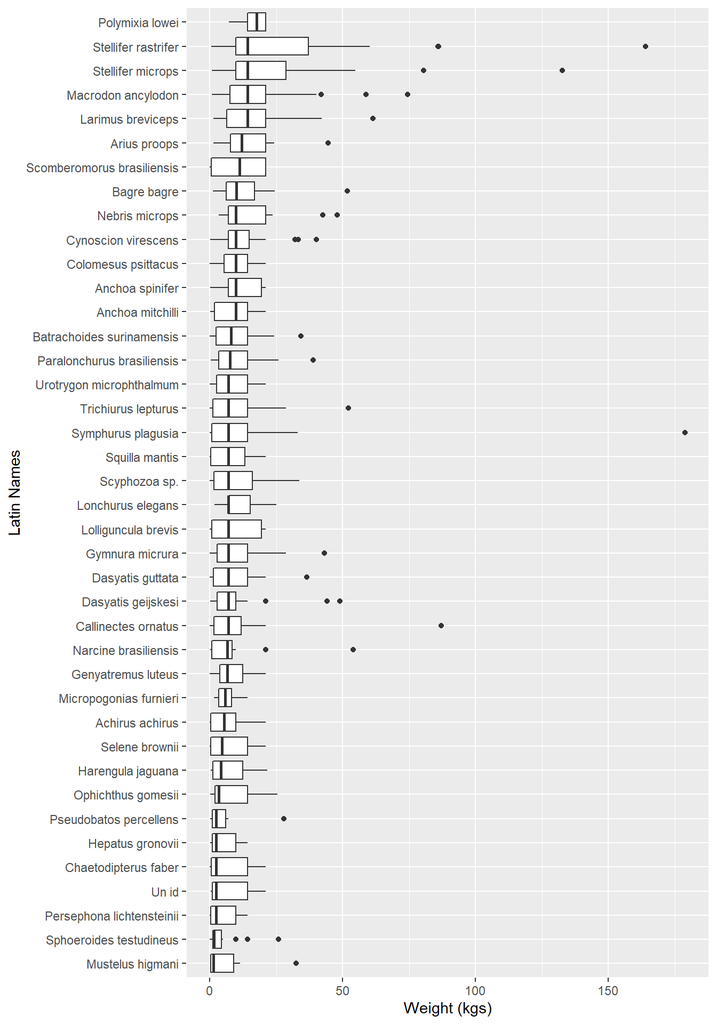

Figure 3 Boxplot showing a breakdown of total weight distribution by species. Ranking is done from the highest (top of plot) to the lowest (bottom of plot).

```r
SpeciesWeights <- DiscardData %>%
  group_by(LatinNames) %>%
  filter(n() >= 5)


Plot1 <- ggplot(data = SpeciesWeights,
       mapping = aes(x = reorder(LatinNames,
                                 TotalWeightKG,
                                 FUN = median),
                     y = TotalWeightKG)) +
  geom_boxplot() +
  coord_flip()  +
  labs(x = "Latin Names",
       y ="Weight (kgs)") +
  theme(panel.background = element_rect(colour = "White"),
        legend.position = "none")

###=== COMMENTS START ===###
### [1]. First the main data "DiscardData" was filtered to remove species that occurred less than five time in sample. This was done using the group_by() and filter() functions from dplyr. This was done to get meaning summary statistics e.g. median and range. The new data is named "SpeciesWeights".
### ==========
### [2]. The first argument to the ggplot() function is the data ("SpeciesWeights"). Then the mapping = aes() where the X variable ("LatinNames") and the Y variable "TotalWeightKG" were supplied. The reorder() function was used to sort the species from the highest(top of plot) to the lowest (bottom of plot) median values.
### ==========
### [3]. The arguments were passed to the geom_boxplot() function.
### ==========
### [4]. The coord_flip() function was used to switch the axis to allow for a better presentation of the data. This was due to the excess species.
### ==========
### [5]. X and Y axis labels were added using the labs() function.
### ==========
### [6]. The plot was formatted using the theme() function and the legend removed using the legend.position argument.
###=== COMMENTS END ===###

Plot1
```

## 1.8 Proportions of the total catch were discarded (Research Question 2)

### 1.8.1 Catch categories

In total 18608 kgs of fish were landed. Of this amount, bony fish accounted for the highest i.e. 8,804 kgs, followed by shellfish (7,240 kgs), flatfish (1,938 kgs) and others (626 kgs) (Figure 4). A similar trend was seen in the mean weights caught per trip for the different categories i.e. bony fish the highest 1,101 kgs/trip, followed by shell fish (905 kgs/trip), flat fish 242 kgs/trip and Others 78 kgs/trip. The minimum and maximum discard landed by category are as follows: bony fish discards ranged from 683 kgs (trip 4) to 2,410 kgs (trip 6), shell fish from 346 kgs (trip 7) to 1,885 kgs (trip 4), flat fish from 18 kgs (trip 1) to 577 kgs (trip 6) and others from 9 kgs to 257 kgs (trip 6) (Figure 4).

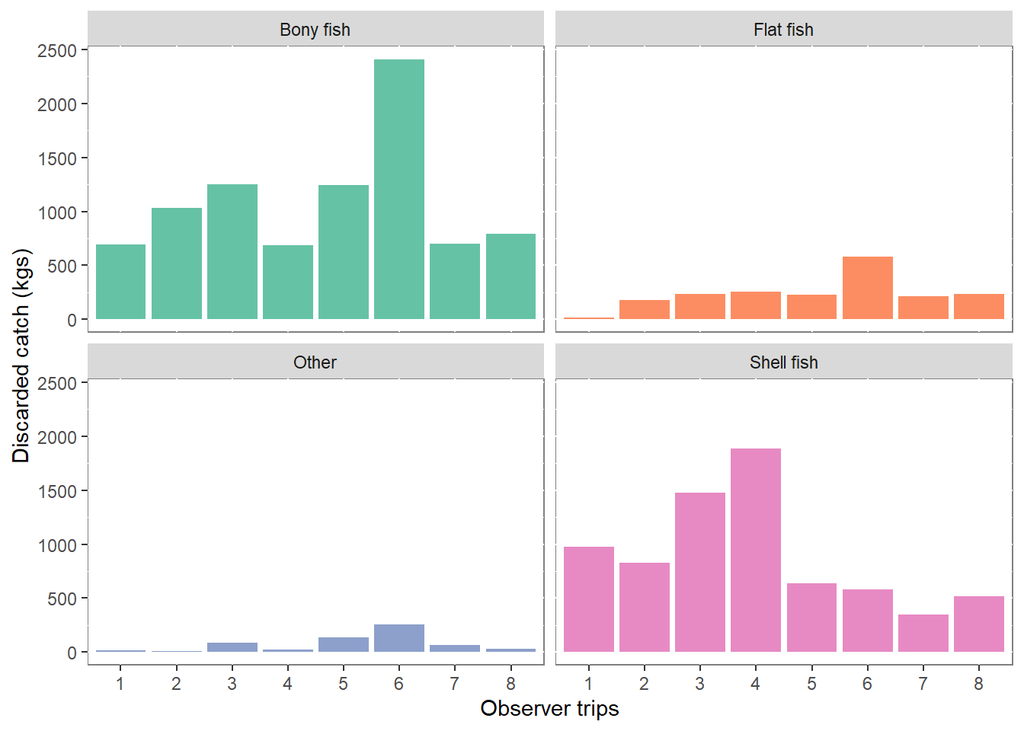

Figure 4 Barplot showing a breakdown of weights by species category across fishing trips

```r
Plot2 <- ggplot(data = ObserverData,
       mapping = aes(x = as.factor(TripID),
                     y = TotalWeightKG,
                     fill = SpeciesCategory2)) +
  geom_bar(stat = "identity") +
  theme(panel.background = element_rect(fill = "white",
                                        colour = "grey50"),
        legend.position = "none") +
  labs(x="Observer trips",
       y = "Discarded catch (kgs)") +
  scale_fill_brewer(palette="Set2") +
  facet_wrap(. ~ SpeciesCategory2)

###=== COMMENTS START ===###
### [1]. Here the Observerdata was used to get the four categories of species caught and to plot them using using four bar plots on a single window using the facet_wrap() function.
### ==========
### [2]. The first argument to the ggplot() function is the data ("ObserverData"). Then the mapping = aes() where the X variable ("TripID") and the Y variable "TotalWeightKG" were supplied.
### ==========
### [3]. The fill argument was used to colour the data by the different categories i.e. "SpeciesCategory2".
### ==========
### [4]. The arguments were passed to the geom_bar() function.
### ==========
### [5]. The plot was formatted using the theme() function and the legend removed using the legend.position argument. Because the names were provide by the facet_wrap() function a legend would have been redundant.
### ==========
### [6]. X and Y axis labels were added using the labs() function.
### ==========
### [7]. The scale_fill_brewer was used to customize the color of the bars according to the species category. The palette argument was used within the function to achieve this.
### ==========
### [8]. Lastly the facet_wrap() function was used to complete the figure.
###=== COMMENTS END ===###

Plot2
```

### 1.8.2 Discard against target species across fishing trips

Of the total fish weight, bycatch species accounted for 11,956 kgs (68%) and target species 5,705 kgs (32%) (Figure 5). Bycatch species proportions (by weight) within the total catch ranged from 37% (trip 4) to 95% (trip 6). Target species on the other hand ranged from 5% (trip 6) to 63% (trip 4) (Figure 5).

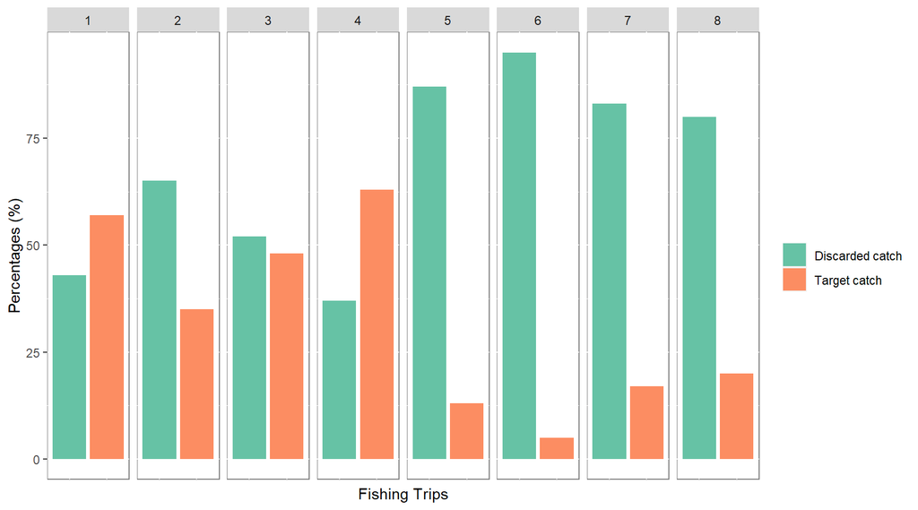

Figure 5 Barplot showing a breakdown of weights (proportions) by catch category for the different fishing trips. The numbers at the top of each pair of bars i.e. in the grey area represents the Fishing Trip number ID

```r
FilteredCatch <- ObserverData %>%
  filter(CatchCategory == "Discarded catch" |
           CatchCategory == "Target catch")

###=== COMMENTS START ===###
### [1]. Filtering the observer data by catch category.
### ###=== COMMENTS END ===###

SumFilteredCatch <- FilteredCatch %>%
  group_by(TripID,
           SpeciesCategory) %>%
  dplyr::summarise(WeightKG = sum(TotalWeightKG),
                   .groups = 'drop') %>%
  group_by(TripID) %>%
  mutate(Percentage = round(prop.table(WeightKG)*100))

###=== COMMENTS START ===###
### [2]. Creating a summary table of weights by fishing trip and species category.
### ==========
### [3]. The group_by() and summarise() functions were used to obtain this along with the sum() function to create a variable called "WeightKG".
### ==========
### [4]. A new variable containing percentages for the different catch categories by fishing trips was created using the prop.table() function from base R. The values were rounded and time(*) 100 to converted to percentage.
###=== COMMENTS END ===###

Plot3 <- ggplot(data = SumFilteredCatch,
                mapping = aes(x = SpeciesCategory,
                              y = Percentage,
                              fill = SpeciesCategory)) +
  geom_col(position = "dodge") +
  theme(panel.background = element_rect(fill = "white",
                                        colour = "grey50"), axis.text.x = element_blank(), axis.ticks.x = element_blank()) +
  labs(x="Fishing Trips",
       y = "Percentages (%)") +
  scale_fill_brewer(palette="Set2",
                    name = " ",
                    labels = c("Discarded catch", "Target catch")) + facet_grid(~TripID)

###=== COMMENTS START ===###
### [1]. The comments here are similar to that made for "Plot1" except: ### ==========
### [2]. The differences here is that geom_col() function was used here in the place of geom_bar() function. This was used to allow "position" dodge argument which places the catch bars side-by-side for easy comparison.
### ==========
### [3]. The theme() function arguments are similar to "Plot1". The only additions are that the X axis ticks and texts were removed using the arguments: axis.ticks.x and axis.text.x, with the function value element_blank().
### ==========
### [4]. The scale_fill_brewer was used to customize the color of  the bars according to the catch category. The palette argument was used within the function to achieve this. The names argument was used to remove the default name and replace with a blank space (" ") and the labels argument to add labels to the plot.
### ==========
### [5]. The fact_grid() function was used to present the data side-by-side by fishing trips.
###=== COMMENTS END ===###

Plot3
```

# 2 SECOND SUBMISSION

## 2.1 **Research Question 3** What are the **weight Distributions** of the **Most Common Species Discarded**?

```r
Table4 <- DiscardData %>%
  group_by(LatinNames) %>%
  dplyr::summarise(Weight = round(sum(TotalWeightKG)),
                                  .groups = 'drop') %>%
  mutate(WeightPct = round((Weight/sum(Weight))*100,2)) %>%
  arrange(desc(Weight)) %>%
  head(31)

colnames(Table4) <-c("Latin Names", "Weights (kgs)", "Weight (%)")

Table4 %>%
  kbl() %>%
  kable_classic() %>%
  row_spec(0, bold = TRUE) %>%
  kable_styling(fixed_thead = T) %>%
  kable_styling(bootstrap_options = c("striped", "condensed")) %>%
   footnote(number = "Un id refers to multiple species which were unidentified and not a single species.")
```

| Latin Names | Weights (kgs) | Weight (%) |
| --- | --- | --- |
| Stellifer rastrifer | 1235 | 10.33 |
| Stellifer microps | 1105 | 9.24 |
| Macrodon ancylodon | 848 | 7.09 |
| Cynoscion virescens | 532 | 4.45 |
| Bagre bagre | 517 | 4.32 |
| Symphurus plagusia | 516 | 4.32 |
| Callinectes ornatus | 425 | 3.55 |
| Nebris microps | 390 | 3.26 |
| Trichiurus lepturus | 384 | 3.21 |
| Paralonchurus brasiliensis | 375 | 3.14 |
| Batrachoides surinamensis | 341 | 2.85 |
| Gymnura micrura | 334 | 2.79 |
| Larimus breviceps | 315 | 2.63 |
| Ophichthus gomesii | 292 | 2.44 |
| Dasyatis guttata | 257 | 2.15 |
| Achirus achirus | 255 | 2.13 |
| Lonchurus elegans | 248 | 2.07 |
| Squilla mantis | 248 | 2.07 |
| Scyphozoa sp. | 245 | 2.05 |
| Colomesus psittacus | 231 | 1.93 |
| Dasyatis geijskesi | 223 | 1.87 |
| Anchoa mitchilli | 215 | 1.80 |
| Harengula jaguana | 210 | 1.76 |
| Arius proops | 209 | 1.75 |
| Anchoa spinifer | 200 | 1.67 |
| Un id | 184 | 1.54 |
| Chaetodipterus faber | 178 | 1.49 |
| Polymixia lowei | 170 | 1.42 |
| Selene brownii | 148 | 1.24 |
| Urotrygon microphthalmum | 126 | 1.05 |
| Hepatus gronovii | 120 | 1.00 |

<sup>1</sup> Un id refers to multiple species which were unidentified and not a single species.

### 2.1.2 Inspection of Weight Data before analysis

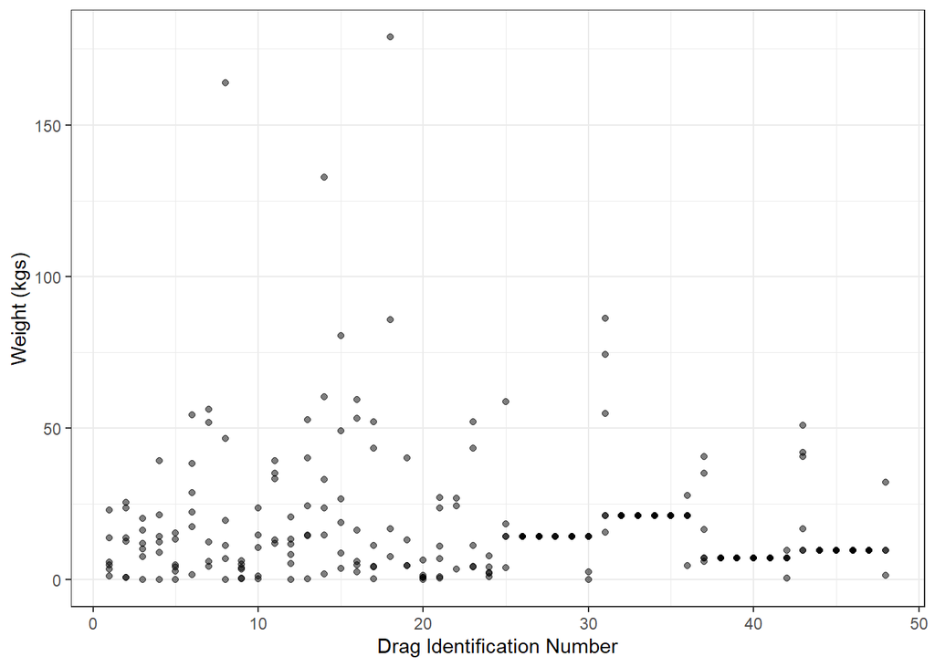

```r
SpeciesNamesTop6 <- head(Table4$`Latin Names`, 6)

SpeciesDataTop6 <- DiscardData %>%
  filter(LatinNames %in% SpeciesNamesTop6)

ggplot(SpeciesDataTop6,
       aes(x = DragID2, y = TotalWeightKG)) +
  geom_point(alpha = 0.5) +
  theme_bw() +
  labs(x = "Drag Identification Number",
       y = "Weight (kgs)")
```

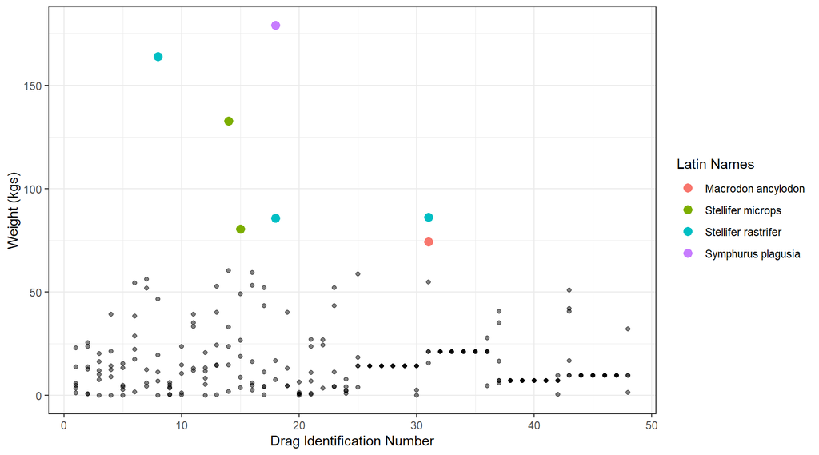

```r
# filter dataframe to get data to be highligheted

HighlightedPoints <- SpeciesDataTop6 %>%
  filter(TotalWeightKG > 61) # Removing 7 abnormally high values, possible outliers
SpeciesDataTop6 %>%
  ggplot() +
  geom_point(aes(x = DragID2,
                 y = TotalWeightKG),
             alpha = 0.5) +
  geom_point(data = HighlightedPoints,
             aes(x = DragID2,
                 y = TotalWeightKG, color = LatinNames),
             size = 3) +
  theme_bw() +
  guides(color=guide_legend(title="Latin Names")) +
  labs(x = "Drag Identification Number",
       y = "Weight (kgs)")
```

```r
SpeciesDataTop6 <- SpeciesDataTop6 %>%
  filter(TotalWeightKG < 61)
```

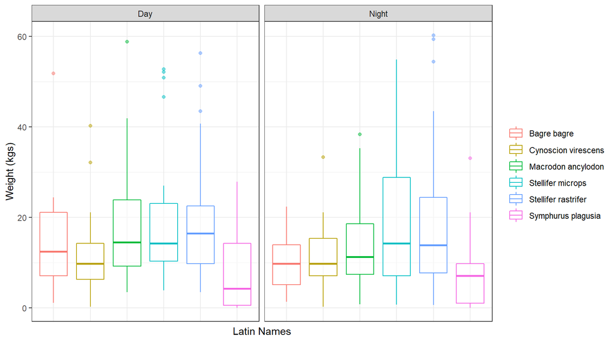

```r
ggplot(SpeciesDataTop6,
       aes(x = LatinNames,
           y = TotalWeightKG,
           colour = LatinNames)) +
  geom_boxplot(alpha = 0.5) +
  theme_bw() +
  theme(panel.background = element_rect(fill = "white",
                                        colour = "grey50"),
        axis.text.x = element_blank(),
        axis.ticks.x = element_blank(),
        legend.title = element_blank()) +
  labs(x = "Latin Names",
       y = "Weight (kgs)") +
  facet_wrap(~TimePeriods, ncol = 2)
```

```r
Table5 <- SpeciesDataTop6 %>%
  group_by(LatinNames,
           TimePeriods) %>%
  dplyr::summarise(SumWeights = round(sum(TotalWeightKG)),
                   MedianWeights = round(median(TotalWeightKG)),                    .groups = 'drop')

Table5 %>%
  kbl() %>%
  kable_classic("striped") %>%
  row_spec(0, bold = TRUE) %>%
  column_spec(1, bold = T) %>%
  kable_styling(fixed_thead = T) %>%
  kable_styling(fixed_thead = T, bootstrap_options = "condensed")
```

| LatinNames | TimePeriods | SumWeights | MedianWeights |
| --- | --- | --- | --- |
| Bagre bagre | Day | 295 | 12 |
| Bagre bagre | Night | 222 | 10 |
| Cynoscion virescens | Day | 278 | 10 |
| Cynoscion virescens | Night | 254 | 10 |
| Macrodon ancylodon | Day | 452 | 14 |
| Macrodon ancylodon | Night | 322 | 11 |
| Stellifer microps | Day | 455 | 14 |
| Stellifer microps | Night | 437 | 14 |
| Stellifer rastrifer | Day | 457 | 16 |
| Stellifer rastrifer | Night | 442 | 14 |
| Symphurus plagusia | Day | 159 | 4 |
| Symphurus plagusia | Night | 178 | 7 |

### 2.1.4 Box plot showing the **Weight distribution** for the **six (6) most Common species discarded** across **Fishing Depths**.

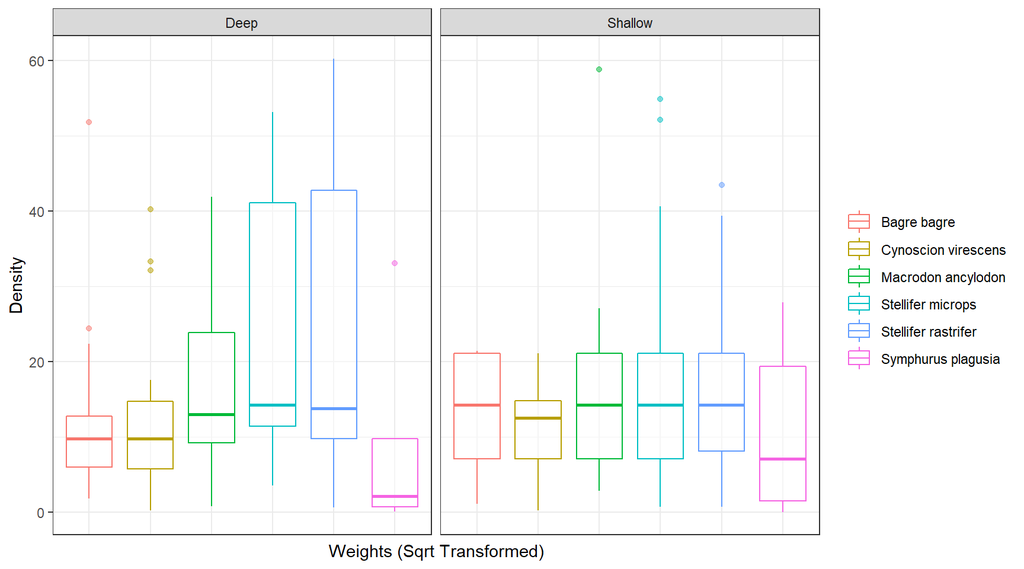

```r
ggplot(SpeciesDataTop6,
       aes(x = LatinNames,
           y = TotalWeightKG,
           colour = LatinNames)) +
  geom_boxplot(alpha = 0.5) +
  theme_bw() +
  theme(panel.background = element_rect(fill = "white",
                                        colour = "grey50"),
        axis.text.x = element_blank(),
        axis.ticks.x = element_blank(),
        legend.title = element_blank())  +
  labs(x = "Weights (Sqrt Transformed)",
       y = "Density") +
  facet_wrap(~FishingDepth2, ncol = 2)
```

```r
Table6 <- SpeciesDataTop6 %>%
  group_by(LatinNames,
           FishingDepth2) %>%
  dplyr::summarise(SumWeights = sum(TotalWeightKG),
                   MedianWeights = median(TotalWeightKG),
                   .groups = 'drop')

Table6 %>%
  kbl() %>%
  kable_classic("striped") %>%
  row_spec(0, bold = TRUE) %>%
  column_spec(1, bold = T) %>%
  kable_styling(fixed_thead = T, bootstrap_options = "condensed")
```

| LatinNames | FishingDepth2 | SumWeights | MedianWeights |
| --- | --- | --- | --- |
| Bagre bagre | Deep | 261.2591 | 9.740909 |
| Bagre bagre | Shallow | 255.4227 | 14.286364 |
| Cynoscion virescens | Deep | 266.6182 | 9.740909 |
| Cynoscion virescens | Shallow | 265.3091 | 12.518182 |
| Macrodon ancylodon | Deep | 416.1318 | 12.975000 |
| Macrodon ancylodon | Shallow | 357.4591 | 14.286364 |
| Stellifer microps | Deep | 490.4818 | 14.284091 |
| Stellifer microps | Shallow | 401.4500 | 14.286364 |
| Stellifer rastrifer | Deep | 525.1045 | 13.811364 |
| Stellifer rastrifer | Shallow | 373.9545 | 14.286364 |
| Symphurus plagusia | Deep | 105.7364 | 2.138636 |
| Symphurus plagusia | Shallow | 231.5955 | 7.086364 |

## 2.2 **Research Question 4** Are the mean species weights equal across **Time-Periods** and **Fishing Depths**?

### 2.2.1 Density plot showing **Discarded Catch** weight distribution for **All Species** across **Time-Periods**.

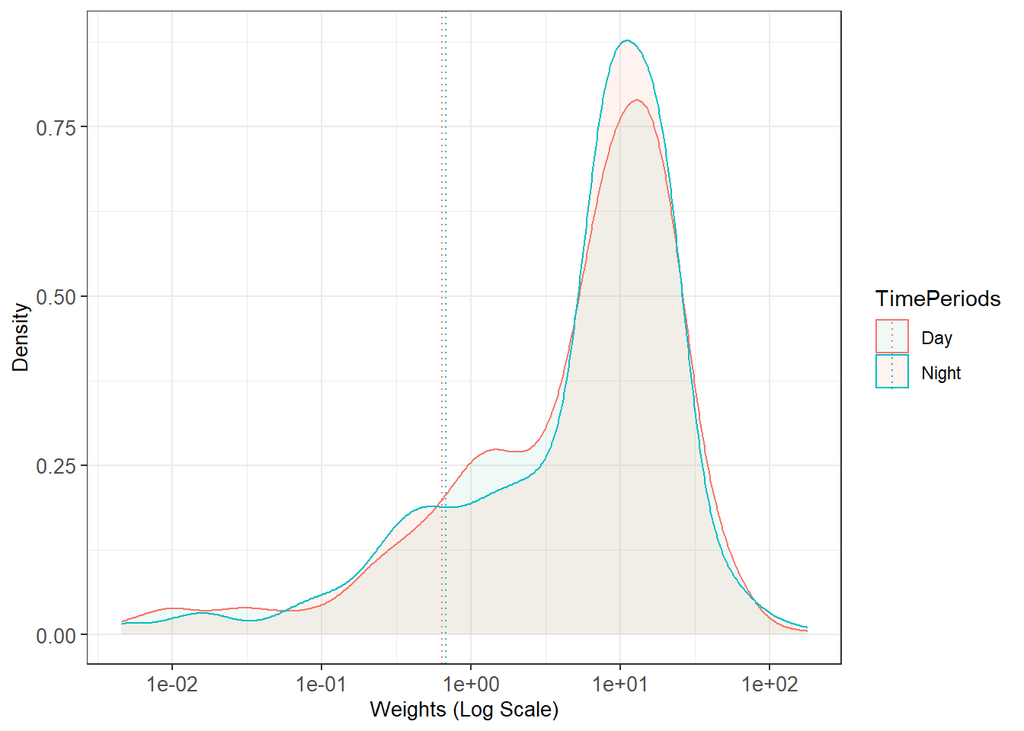

```r
MeanTP <- DiscardData %>%
  group_by(TimePeriods) %>%
  dplyr::summarise(MeanWeight = mean(log10(TotalWeightKG)), .groups = 'drop')

ggplot(DiscardData,
       aes(TotalWeightKG,
           color = TimePeriods,
           fill = TimePeriods)) +
  geom_density(alpha = 0.1) +
  theme_bw() +
  theme(axis.text = element_text(size = 10),
        axis.title = element_text(size = 10)) +
  scale_fill_brewer(palette = "Set2") +
  labs(x = "Weights (Log Scale)",
       y = "Density") +
  scale_x_continuous(trans = "log10") +
  geom_vline(data = MeanTP,
             aes(xintercept = MeanWeight,
                 color = TimePeriods),
             linetype = "dotted",
             size = 0.5)
```

### 2.2.2 Analysis of the **Mean Discarded Catch** across **Time-Periods** using the Two Sample T-test.

```r
WeightTestTP <- t.test(TotalWeightKG ~ TimePeriods,
       data = DiscardData)

WeightTestTP
```

```
    Welch Two Sample t-test

  data:  TotalWeightKG by TimePeriods
  t = -0.63073, df = 1031.8, p-value = 0.5284
  alternative hypothesis: true difference in means is not equal to 0
  95 percent confidence interval:
   -2.217405  1.138669
  sample estimates:
    mean in group Day mean in group Night
             10.88113            11.42050
```

### 2.2.3 Density plot showing **Discarded Catch** weight distribution for **All Species** across **Fishing Depths**.

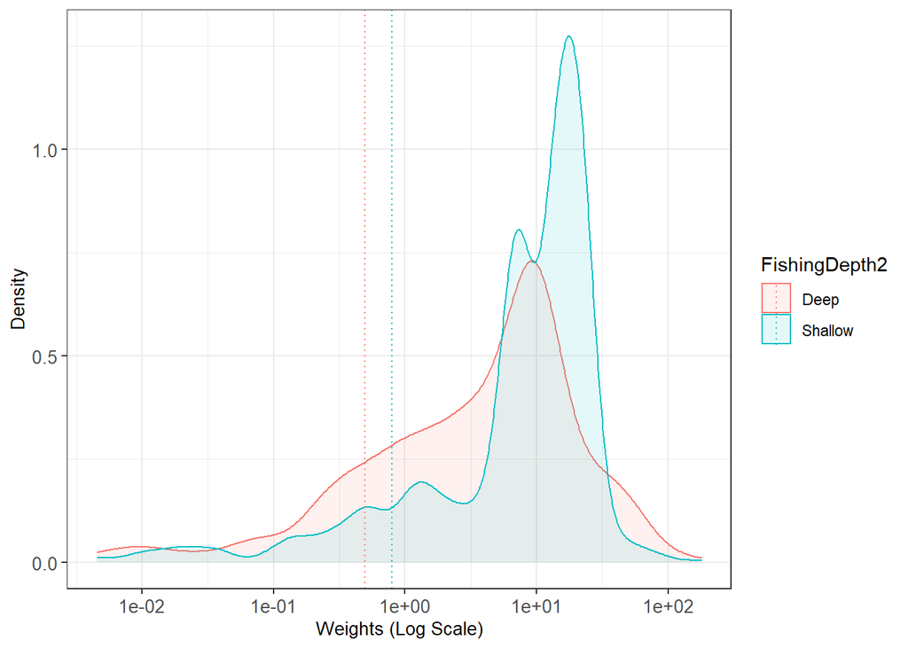

```r
MeanFD <- DiscardData %>%
  group_by(FishingDepth2) %>%
  dplyr::summarise(MeanWeight = mean(log10(TotalWeightKG)), .groups = 'drop')

ggplot(DiscardData,
       aes(TotalWeightKG,
           color = FishingDepth2,
           fill = FishingDepth2)) +
  geom_density(alpha = 0.1) +
  theme_bw() +
  theme(axis.text = element_text(size = 10),
        axis.title = element_text(size = 10)) +
  labs(x = "Weights (Log Scale)",
       y = "Density") +
  scale_x_continuous(trans = "log10") +
  geom_vline(data = MeanFD,
             aes(xintercept = MeanWeight,
                 color = FishingDepth2),
             linetype = "dotted",
             size = 0.5)
```

### 2.2.4 Analysis of the **Mean Discarded Catch** across **Fishing Depths** using the Two Sample T-test.

```r
WeightTestFD <- t.test(TotalWeightKG ~ FishingDepth2,
       data = DiscardData)

WeightTestFD
```

```
    Welch Two Sample t-test

  data:  TotalWeightKG by FishingDepth2
  t = -3.0285, df = 910.71, p-value = 0.002527
  alternative hypothesis: true difference in means is not equal to 0
  95 percent confidence interval:
   -4.3470092 -0.9283741
  sample estimates:
     mean in group Deep mean in group Shallow
               9.697582             12.335274
```

# 3 THIRD SUBMISSION (Joining weight and length data)

```r
LengthImport <- read_csv("observer_lengths_mas102m.csv")

LengthData <- inner_join(DiscardData, LengthImport, by = c("TripID", "DragID2", "LatinNames"))

CheckData <- LengthData %>%
  group_by(LatinNames, FishingDepth2) %>%
  dplyr::summarise()

NoDuplicates <- c("Anchoa spinifer", "Larimus breviceps", "Lonchurus elegans", "Shallow", "Trichiurus lepturus")

LengthData <- LengthData %>%
  filter(!LatinNames %in% NoDuplicates)
```

### 3.1.1 **Length Distributions** of the **Species Discarded**

```r
Table7 <- LengthData %>%
  group_by(LatinNames) %>%
  dplyr::summarise(MeanLength = round(mean(Lengths)),
                   Abundance = n(),
                   .groups = 'drop') %>%
  mutate(AbundancePct = round((Abundance/sum(Abundance))*100,2)) %>%
  arrange(desc(Abundance))

colnames(Table7) <-c("Latin Names", "Mean Lengths (cm)", "Quantity measured (no.)", "Perc. measured (%)")

Table7 %>%
  kbl(caption = "Table 7 showing the length distributions and abundance of the species discarded") %>%
  kable_classic() %>%
  row_spec(0, bold = TRUE) %>%
  kable_styling(fixed_thead = T) %>%
  kable_styling(bootstrap_options = c("striped", "condensed"))
```

Table 7 showing the length distributions and abundance of the species discarded

| Latin Names | Mean Lengths (cm) | Quantity measured (no.) | Perc. measured (%) |
| --- | --- | --- | --- |
| Stellifer rastrifer | 10 | 989 | 30.59 |
| Stellifer microps | 12 | 718 | 22.21 |
| Macrodon ancylodon | 17 | 480 | 14.85 |
| Nebris microps | 13 | 262 | 8.10 |
| Bagre bagre | 12 | 239 | 7.39 |
| Cynoscion virescens | 18 | 215 | 6.65 |
| Harengula jaguana | 11 | 121 | 3.74 |
| Symphurus plagusia | 13 | 120 | 3.71 |
| Paralonchurus brasiliensis | 11 | 89 | 2.75 |

### 3.1.2 Inspection of Length Data before analysis

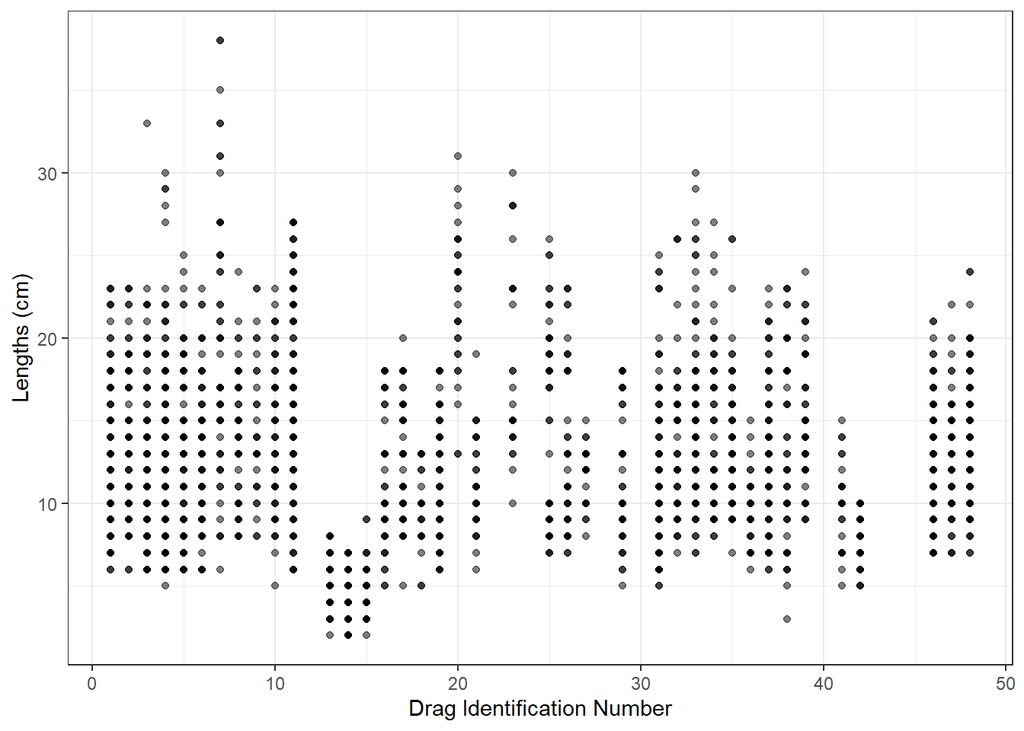

```r
SpeciesNamesTop6 <- head(Table7$`Latin Names`, 6)

SpeciesDataTop6 <- LengthData %>%
  filter(LatinNames %in% SpeciesNamesTop6)

ggplot(SpeciesDataTop6,
       aes(x = DragID2, y = Lengths)) +
  geom_point(alpha = 0.5) +
  theme_bw() +
  labs(x = "Drag Identification Number",
       y = "Lengths (cm)")
```

### 3.1.3 Box plot showing the **Length Distributions** of the **Six (6) most Common Species Discarded** across **Time-Periods**.

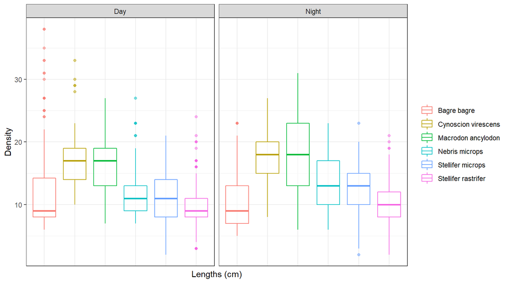

```r
SpeciesNamesTop6 <- head(Table7$`Latin Names`, 6)

SpeciesDataTop6 <- LengthData %>%
  filter(LatinNames %in% SpeciesNamesTop6)

ggplot(SpeciesDataTop6,
       aes(x = LatinNames,
           y = Lengths,
           colour = LatinNames)) +
  geom_boxplot(alpha = 0.5) +
  theme_bw() +
  theme(panel.background = element_rect(fill = "white",
                                        colour = "grey50"),
        axis.text.x = element_blank(),
        axis.ticks.x = element_blank(),
        legend.title = element_blank()) +
  scale_fill_brewer(palette = "Set3") +
  labs(x = "Lengths (cm)",
       y = "Density") +
  facet_wrap(~TimePeriods, ncol = 2)
```

```r
Table8 <- SpeciesDataTop6 %>%
  group_by(LatinNames,
           TimePeriods) %>%
  dplyr::summarise(MeanLengths = round(mean(Lengths)),
                   .groups = 'drop')

Table8 %>%
  kbl() %>%
  kable_classic("striped") %>%
  row_spec(0, bold = TRUE) %>%
  column_spec(1, bold = T) %>%
  kable_styling(fixed_thead = T) %>%
  kable_styling(fixed_thead = T, bootstrap_options = "condensed")
```

| LatinNames | TimePeriods | MeanLengths |
| --- | --- | --- |
| Bagre bagre | Day | 13 |
| Bagre bagre | Night | 10 |
| Cynoscion virescens | Day | 17 |
| Cynoscion virescens | Night | 18 |
| Macrodon ancylodon | Day | 16 |
| Macrodon ancylodon | Night | 18 |
| Nebris microps | Day | 12 |
| Nebris microps | Night | 14 |
| Stellifer microps | Day | 11 |
| Stellifer microps | Night | 12 |
| Stellifer rastrifer | Day | 9 |
| Stellifer rastrifer | Night | 10 |

### 3.1.4 Box plot showing the **Length distribution** for the **six (6)** most Common species across **Fishing Depths**.

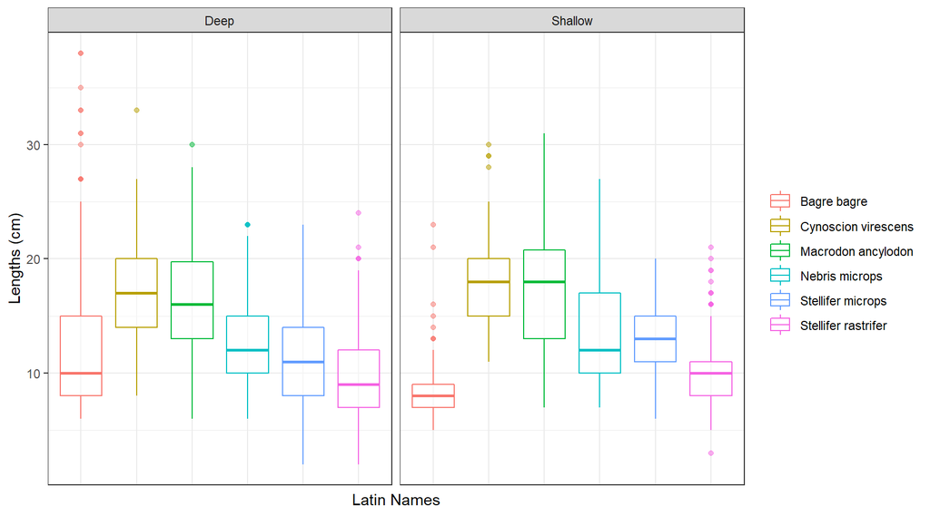

```r
ggplot(SpeciesDataTop6,
       aes(x = LatinNames,
           y = Lengths,
           colour = LatinNames)) +
  geom_boxplot(alpha = 0.5) +
  theme_bw() +
  theme(panel.background = element_rect(fill = "white",
                                        colour = "grey50"),
        axis.text.x = element_blank(),
        axis.ticks.x = element_blank(),
        legend.title = element_blank()) +
  labs(x = "Latin Names",
       y = "Lengths (cm)") +
  facet_wrap(~FishingDepth2, ncol= 2)
```

```r
Table9 <- SpeciesDataTop6 %>%
  group_by(LatinNames,
           FishingDepth2) %>%
  dplyr::summarise(MeanLengths = round(mean(Lengths)),
                   .groups = 'drop')

Table9 %>%
  kbl() %>%
  kable_classic("striped") %>%
  row_spec(0, bold = TRUE) %>%
  column_spec(1, bold = T) %>%
  kable_styling(fixed_thead = T) %>%
  kable_styling(fixed_thead = T, bootstrap_options = "condensed")
```

| LatinNames | FishingDepth2 | MeanLengths |
| --- | --- | --- |
| Bagre bagre | Deep | 13 |
| Bagre bagre | Shallow | 9 |
| Cynoscion virescens | Deep | 18 |
| Cynoscion virescens | Shallow | 18 |
| Macrodon ancylodon | Deep | 17 |
| Macrodon ancylodon | Shallow | 17 |
| Nebris microps | Deep | 13 |
| Nebris microps | Shallow | 13 |
| Stellifer microps | Deep | 11 |
| Stellifer microps | Shallow | 13 |
| Stellifer rastrifer | Deep | 9 |
| Stellifer rastrifer | Shallow | 10 |

### 3.2.1 Density plot showing the distribution of **Discarded Catch Lengths** for **All Species** across **Time-Periods**.

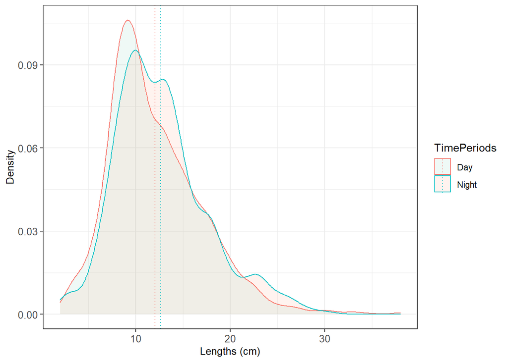

```r
MeanLengthTP <- LengthData %>%
  group_by(TimePeriods) %>%
  dplyr::summarise(MeanLength = mean(Lengths),
                   .groups = 'drop')

ggplot(LengthData,
       aes(Lengths,
           color = TimePeriods,
           fill = TimePeriods)) +
  geom_density(alpha = 0.1) +
  theme_bw() +
  theme(axis.text = element_text(size = 10),
        axis.title = element_text(size = 10)) +
  scale_fill_brewer(palette = "Set2") +
  labs(x = "Lengths (cm)",
       y = "Density") +
  geom_vline(data = MeanLengthTP,
             aes(xintercept = MeanLength,
                 color = TimePeriods),
             linetype = "dotted",
             size = 0.5)
```

### 3.2.2 An analysis of the **Mean Discarded Catch Lengths** across **Time-Periods** using the Two Sample T-test.

```r
LengthTestTP <- t.test(Lengths ~ TimePeriods,
       data = LengthData)

LengthTestTP
```

```
    Welch Two Sample t-test

  data:  Lengths by TimePeriods
  t = -3.4968, df = 3216.3, p-value = 0.0004773
  alternative hypothesis: true difference in means is not equal to 0
  95 percent confidence interval:
   -0.9415707 -0.2650179
  sample estimates:
    mean in group Day mean in group Night
             12.06015            12.66345
```

### 3.2.3 Density plot showing the distribution of **Discarded Catch Lengths** for **All Species** across **Fishing Depths**.

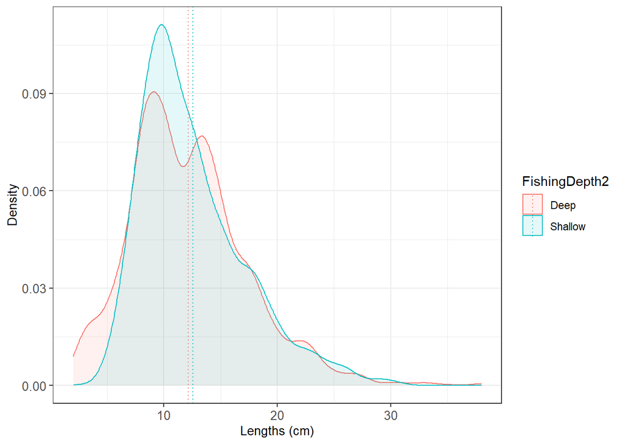

```r
MeanLengthFD <- LengthData %>%
  group_by(FishingDepth2) %>%
  dplyr::summarise(MeanLength = mean(Lengths),
                   .groups = 'drop')

ggplot(LengthData,
       aes(x = Lengths,
           color = FishingDepth2,
           fill = FishingDepth2)) +
  geom_density(alpha = 0.1) +
  theme_bw() +
  theme(axis.text = element_text(size = 10),
        axis.title = element_text(size = 10)) +
  labs(x = "Lengths (cm)",
       y = "Density") +
  geom_vline(data = MeanLengthFD,
             aes(xintercept = MeanLength,
                 color = FishingDepth2),
             linetype = "dotted",
             size = 0.5)
```

### 3.2.4 Analysis of the **Mean Discarded Catch** across **Fishing Depths** using the Two Sample T-test.

```r
WeightTestFD <- t.test(Lengths ~ FishingDepth2,
       data = LengthData)

WeightTestFD
```

```
    Welch Two Sample t-test

  data:  Lengths by FishingDepth2
  t = -2.1712, df = 3224.7, p-value = 0.02999
  alternative hypothesis: true difference in means is not equal to 0
  95 percent confidence interval:
   -0.71122364 -0.03622657
  sample estimates:
     mean in group Deep mean in group Shallow
               12.16946              12.54319
```